# Who and what makes a profit in the movie industry ?:

### Who are actors that tend to play in profitable movies ?

### Who tends to direct profitable movies?

### What genres tend to be profitable ?

- Introduction
- Data Wrangling
- Exploratory Data Analysis
- Actors
- Directors
- Genres
- Conclusions

## Introduction

In this project I am trying to look at the characteristics of money making movies from the perspective of an investor in a movie. The main question that I am trying to answer with this project is

> Which actors, directors and genres should an investor look at when he wants to invest his money in a new movie project ?

The data used in this project is a cleaned version of the IMDB database.

In this project a profitable project is a movie that succeeds to cover it's costs - that is a movie where the difference between the budget and the revenue is positive (it makes a profit).

In order to find these kind of movies we will be looking at who tends to star in these movies, who tends to direct them and what genre they tend to be.

It might sound like logical acrobatics, but the approach that I am using to determine the answers in the title is as follows:  
I will compute the average profit of the movies in which an actor plays, this way if actor Syl played in 10 movies and all these movies had a profit 100 USD it means that the average profits of the movies in which Syl played is 100. I will also do this for the Directors and Genres categories This is not a perfect approach, in fact, let's be honest, it has very many flows, what does it measure is if the actor tends to play, on average in profitable movies or in less profitable ones.  
as I said earlier, Iwill proceed in similar fashion for directors and genres

```python
# taking care of the imports outlining the pandas version '1.0.1' used in this project
import pandas as pd
import numpy as np
import matplotlib.pyplot as plt
%matplotlib inline
pd.__version__
```

```
'1.0.1'
```

## Data Wrangling

In this section we will look more closely at the data in order to geet a feel of it and possibly to "clean" the data.

### General Properties

```python
# reading the data
movies_df = pd.read_csv('tmdb-movies.csv')
movies_df.head(1)
```

|  | id | imdb_id | popularity | budget | revenue | original_title | cast | homepage | director | tagline | ... | overview | runtime | genres | production_companies | release_date | vote_count | vote_average | release_year | budget_adj | revenue_adj |
| --- | --- | --- | --- | --- | --- | --- | --- | --- | --- | --- | --- | --- | --- | --- | --- | --- | --- | --- | --- | --- | --- |
| 0 | 135397 | tt0369610 | 32.985763 | 150000000 | 1513528810 | Jurassic World | Chris Pratt\|Bryce Dallas Howard\|Irrfan Khan\|Vi... | http://www.jurassicworld.com/ | Colin Trevorrow | The park is open. | ... | Twenty-two years after the events of Jurassic ... | 124 | Action\|Adventure\|Science Fiction\|Thriller | Universal Studios\|Amblin Entertainment\|Legenda... | 6/9/15 | 5562 | 6.5 | 2015 | 1.379999e+08 | 1.392446e+09 |

1 rows × 21 columns

### The structure of the Data

```python
movies_df.info()
```

```
<class 'pandas.core.frame.DataFrame'>
RangeIndex: 10866 entries, 0 to 10865
Data columns (total 21 columns):
 #   Column                Non-Null Count  Dtype
---  ------                --------------  -----
 0   id                    10866 non-null  int64
 1   imdb_id               10856 non-null  object
 2   popularity            10866 non-null  float64
 3   budget                10866 non-null  int64
 4   revenue               10866 non-null  int64
 5   original_title        10866 non-null  object
 6   cast                  10790 non-null  object
 7   homepage              2936 non-null   object
 8   director              10822 non-null  object
 9   tagline               8042 non-null   object
 10  keywords              9373 non-null   object
 11  overview              10862 non-null  object
 12  runtime               10866 non-null  int64
 13  genres                10843 non-null  object
 14  production_companies  9836 non-null   object
 15  release_date          10866 non-null  object
 16  vote_count            10866 non-null  int64
 17  vote_average          10866 non-null  float64
 18  release_year          10866 non-null  int64
 19  budget_adj            10866 non-null  float64
 20  revenue_adj           10866 non-null  float64
dtypes: float64(4), int64(6), object(11)
memory usage: 1.7+ MB
```

As you can see there are 21 columns with 10866 rows of which there are columns who contain missing values. Given the original questions and the aim of the project we will be only using the information in columns

**"budget"**,  
**"revenue",**  
**"original title",**  
**"cast"** - which contains the actors that play in the movie,  
**"director",**  
**"release_date",**  
**"budget_adj"** - which contains the costs adjusted in 2010 USD  
**"revenue_adj"** - whch contains the revenue adjusted in 2010 USD  
Moreover a new column will be added **profit_adj** where the difference between **revenue_adj** and release_date **budget_adj**

```python
# removing the columns that are not in focus
movies_df.drop(movies_df.columns[[0, 1, 2,7,9,10,11, 12,14,16,17, 18]], axis = 1,  inplace = True)
```

```python
# adding the "profit_adj" column
movies_df['profit_adj'] = movies_df['revenue_adj'] - movies_df['budget_adj']
```

```python
# visualizing the new structure of the data
movies_df.info();
```

```
<class 'pandas.core.frame.DataFrame'>
RangeIndex: 10866 entries, 0 to 10865
Data columns (total 10 columns):
 #   Column          Non-Null Count  Dtype
---  ------          --------------  -----
 0   budget          10866 non-null  int64
 1   revenue         10866 non-null  int64
 2   original_title  10866 non-null  object
 3   cast            10790 non-null  object
 4   director        10822 non-null  object
 5   genres          10843 non-null  object
 6   release_date    10866 non-null  object
 7   budget_adj      10866 non-null  float64
 8   revenue_adj     10866 non-null  float64
 9   profit_adj      10866 non-null  float64
dtypes: float64(3), int64(2), object(5)
memory usage: 849.0+ KB
```

We deleted the columns that we will not be using and added another one **"profit_adj"** , however there are columns that are having missing values. The first column to be examined is the **"cast"** Let's have a look at the missing values in this column

```python
movies_df[movies_df['cast'].isnull()].head()
```

|  | budget | revenue | original_title | cast | director | genres | release_date | budget_adj | revenue_adj | profit_adj |
| --- | --- | --- | --- | --- | --- | --- | --- | --- | --- | --- |
| 371 | 0 | 0 | Sanjay's Super Team | NaN | Sanjay Patel | Animation | 11/25/15 | 0.0 | 0.0 | 0.0 |
| 441 | 0 | 0 | Winter on Fire: Ukraine's Fight for Freedom | NaN | Evgeny Afineevsky | Documentary | 10/9/15 | 0.0 | 0.0 | 0.0 |
| 465 | 0 | 0 | Bitter Lake | NaN | Adam Curtis | Documentary | 1/24/15 | 0.0 | 0.0 | 0.0 |
| 536 | 0 | 0 | A Faster Horse | NaN | David Gelb | Documentary | 10/8/15 | 0.0 | 0.0 | 0.0 |
| 538 | 0 | 0 | The Mask You Live In | NaN | Jennifer Siebel Newsom | Documentary | 1/1/15 | 0.0 | 0.0 | 0.0 |

The above selection contains a selection of null values from the **"cast"** column. Having a closer look we see that the cast is missing where the  
genre  
is animation or documentary which is quite logical - there cannot be any actors in a documentary or animation movies, but, what other categories are there in the **"genres"** column

```python
movies_df[movies_df['cast'].isnull()]['genres'].unique()
```

```
array(['Animation', 'Documentary', 'Science Fiction|Action|Animation',
       nan, 'Animation|Comedy|Science Fiction', 'War|Documentary',
       'Documentary|Thriller', 'Drama|Comedy|Family',
       'Animation|Fantasy|Mystery', 'Animation|Comedy',
       'Documentary|History|War', 'Family', 'Animation|Family|Fantasy',
       'Animation|Comedy|Family', 'Foreign|Documentary',
       'Adventure|Animation', 'Drama|Animation',
       'Documentary|Drama|Music|Thriller',
       'Fantasy|Animation|Comedy|Drama', 'Documentary|History',
       'Animation|Family', 'Animation|Fantasy', 'Animation|Family|Music',
       'Animation|Action', 'Animation|Drama', 'Documentary|Drama|Music',
       'Action|Adventure|Animation|Family|Fantasy', 'Drama'], dtype=object)
```

Interesting there are also null values in the **"genres"** column, yet most of them contain either "documentary" or "animation" as their respective genre. Definetely, there are also exceptions such as "Drama" or "Family"  
Before going any further let's how many instances where cast is null are there ?

```python
movies_df['cast'].isnull().sum()
```

```
76
```

Well, while it looked like fun to investigate the cases where cast has no value, the number of these cases are too low to impact the anwers we posed at the begining of this project, therefore, all the movies where there is no **cast** value will be removed

```python
# removing the rows where null values in the cast column are present
movies_df.dropna(subset=['cast'], inplace = True)
# visual chech of the removed values (there should be values)
movies_df[movies_df['cast'].isnull()].head()
```

|  | budget | revenue | original_title | cast | director | genres | release_date | budget_adj | revenue_adj | profit_adj |
| --- | --- | --- | --- | --- | --- | --- | --- | --- | --- | --- |

```python
# new structure of data
movies_df.info()
```

```
<class 'pandas.core.frame.DataFrame'>
Int64Index: 10790 entries, 0 to 10865
Data columns (total 10 columns):
 #   Column          Non-Null Count  Dtype
---  ------          --------------  -----
 0   budget          10790 non-null  int64
 1   revenue         10790 non-null  int64
 2   original_title  10790 non-null  object
 3   cast            10790 non-null  object
 4   director        10752 non-null  object
 5   genres          10768 non-null  object
 6   release_date    10790 non-null  object
 7   budget_adj      10790 non-null  float64
 8   revenue_adj     10790 non-null  float64
 9   profit_adj      10790 non-null  float64
dtypes: float64(3), int64(2), object(5)
memory usage: 927.3+ KB
```

Let's have a look at another column where there are missing values, the **"director"** column.  
Since there are not many null values, we can visualy inspect them let's see >>>>

```python
movies_df[movies_df['director'].isnull()]
```

|  | budget | revenue | original_title | cast | director | genres | release_date | budget_adj | revenue_adj | profit_adj |
| --- | --- | --- | --- | --- | --- | --- | --- | --- | --- | --- |
| 532 | 0 | 0 | Iliza Shlesinger: Freezing Hot | Iliza Shlesinger | NaN | Comedy | 1/23/15 | 0.000000e+00 | 0.000000e+00 | 0.000000e+00 |
| 548 | 0 | 0 | Sense8: Creating the World | Tuppence Middleton\|Bae Doona \|Brian J. Smith\|A... | NaN | Documentary\|Science Fiction | 8/10/15 | 0.000000e+00 | 0.000000e+00 | 0.000000e+00 |
| 556 | 0 | 0 | With This Ring | Regina Hall\|Jill Scott\|Eve\|Brooklyn Sudano\|Dei... | NaN | Comedy\|Romance | 1/24/15 | 0.000000e+00 | 0.000000e+00 | 0.000000e+00 |
| 1032 | 0 | 0 | Marvel Studios: Assembling a Universe | Robert Downey Jr.\|Chris Hemsworth\|Chris Evans\|... | NaN | TV Movie\|Documentary | 3/18/14 | 0.000000e+00 | 0.000000e+00 | 0.000000e+00 |
| 1054 | 0 | 0 | Unlocking Sherlock | Benedict Cumberbatch\|Martin Freeman\|Steven Mof... | NaN | TV Movie\|Documentary | 1/19/14 | 0.000000e+00 | 0.000000e+00 | 0.000000e+00 |
| 1203 | 150000 | 0 | Free to Play | Benedict Lim\|Danil Ishutin\|Clinton Loomis | NaN | Documentary | 3/19/14 | 1.381637e+05 | 0.000000e+00 | -1.381637e+05 |
| 1241 | 0 | 0 | Dance-Off | Kathryn McCormick\|Shane Harper\|Finola Hughes\|C... | NaN | Romance\|Music\|Comedy | 1/1/14 | 0.000000e+00 | 0.000000e+00 | 0.000000e+00 |
| 1288 | 0 | 0 | Top Gear: The Perfect Road Trip 2 | Jeremy Clarkson\|Richard Hammond | NaN | Documentary | 11/17/14 | 0.000000e+00 | 0.000000e+00 | 0.000000e+00 |
| 1852 | 0 | 0 | The Diary of Anne Frank | Ellie Kendrick\|Kate Ashfield\|Geoff Breton\|Feli... | NaN | Drama | 1/9/09 | 0.000000e+00 | 0.000000e+00 | 0.000000e+00 |
| 1872 | 3250000 | 0 | Paa | Amitabh Bachchan\|Abhishek Bachchan\|Vidya Balan... | NaN | Drama\|Family\|Foreign | 12/4/09 | 3.303301e+06 | 0.000000e+00 | -3.303301e+06 |
| 1895 | 0 | 0 | Doctor Who: The Waters of Mars | David Tennant | NaN | Science Fiction\|Adventure\|Family | 12/19/09 | 0.000000e+00 | 0.000000e+00 | 0.000000e+00 |
| 2221 | 0 | 0 | Scott Pilgrim vs. the Animation | Michael Cera\|Alison Pill\|Georgette Perna\|Mae W... | NaN | TV Movie\|Animation\|Adventure | 8/10/10 | 0.000000e+00 | 0.000000e+00 | 0.000000e+00 |
| 2286 | 0 | 0 | Bo Burnham: Words, Words, Words | Bo Burnham | NaN | Comedy | 10/19/10 | 0.000000e+00 | 0.000000e+00 | 0.000000e+00 |
| 2290 | 0 | 0 | Across the Line: The Exodus of Charlie Wright | Aidan Quinn\|Andy García\|Mario Van Peebles\|Dan... | NaN | Drama\|Action\|Thriller\|Crime | 12/28/10 | 0.000000e+00 | 0.000000e+00 | 0.000000e+00 |
| 2315 | 0 | 0 | Listen to Your Heart | Alexia Rasmussen\|Kent Moran\|Cybill Shepherd\|Sh... | NaN | Drama\|Music\|Romance | 8/14/10 | 0.000000e+00 | 0.000000e+00 | 0.000000e+00 |
| 2318 | 0 | 0 | Barbie in A Mermaid Tale | Kelly Sheridan\|Kathleen Barr\|Nakia Burrise\|Gar... | NaN | Animation\|Family\|Fantasy | 1/26/10 | 0.000000e+00 | 0.000000e+00 | 0.000000e+00 |
| 2376 | 0 | 0 | Doctor Who: A Christmas Carol | Matt Smith\|Karen Gillan\|Arthur Darvill\|Michael... | NaN | NaN | 12/25/10 | 0.000000e+00 | 0.000000e+00 | 0.000000e+00 |
| 2401 | 0 | 0 | Opeth: In Live Concert At The Royal Albert Hall | Mikael Åkerfeldt\|Martin "Axe" Axenrot\|Martin ... | NaN | Music | 9/21/10 | 0.000000e+00 | 0.000000e+00 | 0.000000e+00 |
| 2403 | 0 | 0 | Yu-Gi-Oh! 3D: Bonds Beyond Time | Greg Abbey\|Dan Green\|Matthew Charles\|Sean Sche... | NaN | Animation\|Fantasy | 1/23/10 | 0.000000e+00 | 0.000000e+00 | 0.000000e+00 |
| 3171 | 0 | 0 | The Assassination of Jesse James: Death Of An ... | Ted Levine\|Casey Affleck\|Brad Pitt\|Mary-Louise... | NaN | Documentary | 1/1/08 | 0.000000e+00 | 0.000000e+00 | 0.000000e+00 |
| 3224 | 0 | 0 | John Mayer: Where the Light Is Live in Los Ang... | John Mayer\|Steve Jordan\|Pino Palladino\|David R... | NaN | Music | 7/1/08 | 0.000000e+00 | 0.000000e+00 | 0.000000e+00 |
| 3276 | 4180000 | 11000000 | Kismat Konnection | Shahid Kapoor\|Vidya Balan\|Juhi Chawla\|Om Puri\|... | NaN | Drama\|Comedy\|Romance\|Foreign | 7/18/08 | 4.233448e+06 | 1.114065e+07 | 6.907205e+06 |
| 3285 | 0 | 0 | Tropic Thunder: Rain of Madness | Justin Theroux\|Jack Black\|Steve Coogan\|Robert ... | NaN | Action\|Comedy | 8/26/08 | 0.000000e+00 | 0.000000e+00 | 0.000000e+00 |
| 3357 | 0 | 0 | Bill Burr: Why Do I Do This? | Bill Burr | NaN | Comedy | 9/23/08 | 0.000000e+00 | 0.000000e+00 | 0.000000e+00 |
| 3365 | 0 | 0 | Foo Fighters: Live at Wembley Stadium | Dave Grohl\|Nate Mendel\|Chris Shiflett\|Pat Smea... | NaN | Music | 8/25/08 | 0.000000e+00 | 0.000000e+00 | 0.000000e+00 |
| 4679 | 0 | 0 | Barbie in A Mermaid Tale 2 | Nakia Burrise\|Gary Chalk | NaN | Animation\|Family | 2/23/12 | 0.000000e+00 | 0.000000e+00 | 0.000000e+00 |
| 4797 | 0 | 0 | Doctor Who: The Snowmen | Matt Smith\|Jenna Coleman\|Richard E. Grant\|Ian ... | NaN | NaN | 12/25/12 | 0.000000e+00 | 0.000000e+00 | 0.000000e+00 |
| 4872 | 0 | 0 | Party Bercy | Florence Foresti | NaN | Comedy | 9/23/12 | 0.000000e+00 | 0.000000e+00 | 0.000000e+00 |
| 5866 | 5000000 | 0 | Jinxed | Ciara Bravo\|Jack Griffo\|Jacob Bertrand\|Elena K... | NaN | Family\|Fantasy\|Comedy | 11/29/13 | 4.680167e+06 | 0.000000e+00 | -4.680167e+06 |
| 5915 | 0 | 0 | Phineas and Ferb: Mission Marvel | Vincent Martella\|Thomas Brodie-Sangster\|Ashley... | NaN | Action\|Adventure\|Science Fiction | 8/16/13 | 0.000000e+00 | 0.000000e+00 | 0.000000e+00 |
| 5972 | 0 | 0 | Top Gear: The Perfect Road Trip | Jeremy Clarkson\|Richard Hammond | NaN | TV Movie\|Action\|Adventure\|Documentary | 11/17/13 | 0.000000e+00 | 0.000000e+00 | 0.000000e+00 |
| 6033 | 0 | 0 | Russell Brand: Messiah Complex | Russell Brand | NaN | Comedy | 11/25/13 | 0.000000e+00 | 0.000000e+00 | 0.000000e+00 |
| 6181 | 0 | 0 | North and South, Book I | Patrick Swayze\|Philip Casnoff\|Kirstie Alley\|Ge... | NaN | Drama\|History\|Western | 11/3/85 | 0.000000e+00 | 0.000000e+00 | 0.000000e+00 |
| 7579 | 0 | 0 | La hora fría | Silke\|Omar Muñoz\|Pepo Oliva\|Carola Manzanares... | NaN | Horror\|Thriller\|Science Fiction\|Mystery\|Foreign | 9/14/07 | 0.000000e+00 | 0.000000e+00 | 0.000000e+00 |
| 7767 | 0 | 0 | Doctor Who: The Runaway Bride | David Tennant\|Catherine Tate | NaN | Science Fiction\|TV Movie | 7/6/07 | 0.000000e+00 | 0.000000e+00 | 0.000000e+00 |
| 7814 | 0 | 0 | Transformers: Beginnings | Peter Cullen\|Frank Welker\|Mark Ryan\|Patrick Ha... | NaN | Animation\|Action\|Thriller\|Science Fiction | 10/16/07 | 0.000000e+00 | 0.000000e+00 | 0.000000e+00 |
| 10386 | 0 | 0 | The Making of 'The Nightmare Before Christmas' | Mike Belzer\|Tim Burton\|Bonita DeCarlo\|Greg Dyk... | NaN | Documentary | 10/3/93 | 0.000000e+00 | 0.000000e+00 | 0.000000e+00 |
| 10426 | 0 | 0 | Magical Mystery Tour | John Lennon\|Paul McCartney\|George Harrison\|Rin... | NaN | Music | 12/25/67 | 0.000000e+00 | 0.000000e+00 | 0.000000e+00 |

Most of the values in the profit are either negative or 0, the positive numbers are few, without a significant impact on the final results - therefore we will be deleting them

```python
# removing movies with null values in the Director column
movies_df.dropna(subset=['director'], inplace = True)
# visual check (there should be no values)
movies_df[movies_df['director'].isnull()].head()
```

|  | budget | revenue | original_title | cast | director | genres | release_date | budget_adj | revenue_adj | profit_adj |
| --- | --- | --- | --- | --- | --- | --- | --- | --- | --- | --- |

```python
# new structure of data
movies_df.info()
```

```
<class 'pandas.core.frame.DataFrame'>
Int64Index: 10752 entries, 0 to 10865
Data columns (total 10 columns):
 #   Column          Non-Null Count  Dtype
---  ------          --------------  -----
 0   budget          10752 non-null  int64
 1   revenue         10752 non-null  int64
 2   original_title  10752 non-null  object
 3   cast            10752 non-null  object
 4   director        10752 non-null  object
 5   genres          10732 non-null  object
 6   release_date    10752 non-null  object
 7   budget_adj      10752 non-null  float64
 8   revenue_adj     10752 non-null  float64
 9   profit_adj      10752 non-null  float64
dtypes: float64(3), int64(2), object(5)
memory usage: 924.0+ KB
```

Last but not least, let's have a look now at the **"genres"** column

```python
movies_df[movies_df['genres'].isnull()]
```

|  | budget | revenue | original_title | cast | director | genres | release_date | budget_adj | revenue_adj | profit_adj |
| --- | --- | --- | --- | --- | --- | --- | --- | --- | --- | --- |
| 424 | 0 | 0 | Belli di papÃ | Diego Abatantuono\|Matilde Gioli\|Andrea Pisani\|... | Guido Chiesa | NaN | 10/29/15 | 0.00000 | 0.0 | 0.00000 |
| 997 | 0 | 0 | Star Wars Rebels: Spark of Rebellion | Freddie Prinze Jr.\|Vanessa Marshall\|Steve Blum... | Steward Lee\|Steven G. Lee | NaN | 10/3/14 | 0.00000 | 0.0 | 0.00000 |
| 1712 | 0 | 0 | Prayers for Bobby | Ryan Kelley\|Sigourney Weaver\|Henry Czerny\|Dan ... | Russell Mulcahy | NaN | 2/27/09 | 0.00000 | 0.0 | 0.00000 |
| 1897 | 0 | 0 | Jonas Brothers: The Concert Experience | Nick Jonas\|Joe Jonas\|Kevin Jonas\|John Lloyd Ta... | Bruce Hendricks | NaN | 2/27/09 | 0.00000 | 0.0 | 0.00000 |
| 2370 | 0 | 0 | Freshman Father | Britt Irvin\|Merrilyn Gann\|Barbara Tyson\|Anthon... | Michael Scott | NaN | 6/5/10 | 0.00000 | 0.0 | 0.00000 |
| 2853 | 0 | 0 | Vizontele | YÄ±lmaz ErdoÄŸan\|Demet Akbag\|Altan Erkekli\|Cem... | YÄ±lmaz ErdoÄŸan | NaN | 2/2/01 | 0.00000 | 0.0 | 0.00000 |
| 3279 | 0 | 0 | ì•„ê¸°ì™€ ë‚˜ | Jang Keun-suk\|Song Ha-yoon\|Kim Jeong-Nan | Kim Jin-Yeong | NaN | 8/13/08 | 0.00000 | 0.0 | 0.00000 |
| 4547 | 0 | 0 | London 2012 Olympic Opening Ceremony: Isles of... | Queen Elizabeth II\|Mike Oldfield\|Kenneth Brana... | Danny Boyle | NaN | 7/27/12 | 0.00000 | 0.0 | 0.00000 |
| 4732 | 0 | 0 | The Scapegoat | Andrew Scott\|Jodhi May\|Eileen Atkins\|Matthew R... | Charles Sturridge | NaN | 9/9/12 | 0.00000 | 0.0 | 0.00000 |
| 4890 | 0 | 0 | Cousin Ben Troop Screening | Jason Schwartzman | Wes Anderson | NaN | 1/1/12 | 0.00000 | 0.0 | 0.00000 |
| 5830 | 0 | 0 | Doctor Who: The Time of the Doctor | Matt Smith\|Jenna Coleman | James Payne | NaN | 12/25/13 | 0.00000 | 0.0 | 0.00000 |
| 5934 | 0 | 0 | Prada: Candy | Peter Gadiot\|Rodolphe Pauly\|LÃ©a Seydoux | Wes Anderson\|Roman Coppola | NaN | 3/25/13 | 0.00000 | 0.0 | 0.00000 |
| 6043 | 0 | 0 | Bombay Talkies | Aamir Khan\|Rani Mukerji\|Randeep Hooda\|Saqib Sa... | Anurag Kashyap\|Dibakar Banerjee\|Zoya Akhtar\|Ka... | NaN | 5/3/13 | 0.00000 | 0.0 | 0.00000 |
| 6530 | 0 | 0 | Saw Rebirth | Whit Anderson\|Stan Kirsch\|Jeff Shuter\|George W... | Jeff Shuter\|Daniel Viney | NaN | 10/24/05 | 0.00000 | 0.0 | 0.00000 |
| 8234 | 0 | 0 | Viaggi di nozze | Carlo Verdone\|Claudia Gerini\|Veronica Pivetti\|... | Carlo Verdone | NaN | 12/15/95 | 0.00000 | 0.0 | 0.00000 |
| 8614 | 0 | 0 | T2 3-D: Battle Across Time | Arnold Schwarzenegger\|Linda Hamilton\|Edward Fu... | James Cameron | NaN | 1/1/96 | 0.00000 | 0.0 | 0.00000 |
| 8878 | 0 | 0 | Mom's Got a Date With a Vampire | Matt O'Leary\|Laura Vandervoort\|Myles Jeffrey\|C... | Steve Boyum | NaN | 10/13/00 | 0.00000 | 0.0 | 0.00000 |
| 9307 | 0 | 0 | Goldeneye | Charles Dance\|Phyllis Logan\|Patrick Ryecart\|La... | Don Boyd | NaN | 8/26/89 | 0.00000 | 0.0 | 0.00000 |
| 9799 | 0 | 0 | The Amputee | Catherine E. Coulson\|David Lynch | David Lynch | NaN | 1/1/74 | 0.00000 | 0.0 | 0.00000 |
| 10659 | 5000 | 0 | The Party at Kitty and Stud's | Sylvester Stallone\|Henrietta Holm\|Nicholas War... | Morton Lewis | NaN | 2/10/70 | 28081.84172 | 0.0 | -28081.84172 |

Whoa!!! everyting in the revenues and budget is 0 with a notable exception **"The Party at Kitty and Stud's"**, that is quite interesting, since we can see a big name there, Stallone. Well I was surprised to see that this movie was actually on the Stallone's first movies, you can read more about it [here](https://en.wikipedia.org/wiki/The_Party_at_Kitty_and_Stud's)  
Again, given the low number of these movies they will be deleted

```python
# removing the rows with the null value in column genres
movies_df.dropna(subset=['genres'], inplace = True)
# visual inspection (there should be no items)
movies_df[movies_df['genres'].isnull()].head()
```

|  | budget | revenue | original_title | cast | director | genres | release_date | budget_adj | revenue_adj | profit_adj |
| --- | --- | --- | --- | --- | --- | --- | --- | --- | --- | --- |

One last thing we will do regarding data cleanliness, the removal of duplicates, if any

```python
movies_df.drop_duplicates(inplace=True)
```

Let's have a look at the data

```python
movies_df.info()
```

```
<class 'pandas.core.frame.DataFrame'>
Int64Index: 10731 entries, 0 to 10865
Data columns (total 10 columns):
 #   Column          Non-Null Count  Dtype
---  ------          --------------  -----
 0   budget          10731 non-null  int64
 1   revenue         10731 non-null  int64
 2   original_title  10731 non-null  object
 3   cast            10731 non-null  object
 4   director        10731 non-null  object
 5   genres          10731 non-null  object
 6   release_date    10731 non-null  object
 7   budget_adj      10731 non-null  float64
 8   revenue_adj     10731 non-null  float64
 9   profit_adj      10731 non-null  float64
dtypes: float64(3), int64(2), object(5)
memory usage: 922.2+ KB
```

Everything looks fine, we have no null values, we have no duplicates, and we have all the data that we need.  
Well, **let the fun begin!!!**

## Exploratory Data Analysis

### Actors

In this section we will be looking at the actors who tend to play in the succesfull movies. To asses this we will compute the average profit of movies the actor has played in.

To do this, first we will create a copy of the initial data frame. The purpose of this copy is to have the integrity of data, meaning that, in case we do something wrong in this section, there will be no need to go to the begining and re-reading the data

```python
actors_df = movies_df.copy()
```

Now, let's have a closer look at the **"cast"** column

```python
type(movies_df['cast'][0])
```

```
str
```

so the type of the data is String, let's how these strings look like

```python
movies_df['cast'][0:5]
```

```
0    Chris Pratt|Bryce Dallas Howard|Irrfan Khan|Vi...
1    Tom Hardy|Charlize Theron|Hugh Keays-Byrne|Nic...
2    Shailene Woodley|Theo James|Kate Winslet|Ansel...
3    Harrison Ford|Mark Hamill|Carrie Fisher|Adam D...
4    Vin Diesel|Paul Walker|Jason Statham|Michelle ...
Name: cast, dtype: object
```

As you can see from above the actors are in strings, and their names are separated by the '|' character.  
next we shall separate them in distinct strings, but first we will select only the columns that we need in this section, that is **"cast"** and **"profit_adj"**

```python
# selecting the columns that we need
actors_df = actors_df[['cast', 'profit_adj']]
# splitting the string by the '|' character
actors_df['cast'] = actors_df['cast'].str.split('|')
actors_df.head()
```

|  | cast | profit_adj |
| --- | --- | --- |
| 0 | [Chris Pratt, Bryce Dallas Howard, Irrfan Khan... | 1.254446e+09 |
| 1 | [Tom Hardy, Charlize Theron, Hugh Keays-Byrne,... | 2.101614e+08 |
| 2 | [Shailene Woodley, Theo James, Kate Winslet, A... | 1.704191e+08 |
| 3 | [Harrison Ford, Mark Hamill, Carrie Fisher, Ad... | 1.718723e+09 |
| 4 | [Vin Diesel, Paul Walker, Jason Statham, Miche... | 1.210949e+09 |

Next, we will divide the cast column in such a way that each actor will have its own row and, as the rule is, every actor who played in that movie will have the same value in the **"profit_adj"** column

```python
actors_df = actors_df.explode('cast')
actors_df.head()
```

|  | cast | profit_adj |
| --- | --- | --- |
| 0 | Chris Pratt | 1.254446e+09 |
| 0 | Bryce Dallas Howard | 1.254446e+09 |
| 0 | Irrfan Khan | 1.254446e+09 |
| 0 | Vincent D'Onofrio | 1.254446e+09 |
| 0 | Nick Robinson | 1.254446e+09 |

In order to have more meaningfull data we shall compute the average profit in adjusted USD for each actor in a new data frame, this way, let's say the Stallone's first movie, the Kitty thing one, had -2000 USD in profit, and Rockie (1976) had 10.000 USD in profit the number next to Stallone will be 4000 (10000 + (-2000))/2

```python
actors_mean_df = actors_df.groupby(actors_df['cast']).mean().reset_index()
actors_mean_df.head()
```

|  | cast | profit_adj |
| --- | --- | --- |
| 0 | Larry Mullen Jr. | 0.000000e+00 |
| 1 | Nicole MuÃ±oz | 0.000000e+00 |
| 2 | Therese Giehse | 0.000000e+00 |
| 3 | "Weird Al" Yankovic | -8.794925e+06 |
| 4 | 50 Cent | 6.512801e+06 |

At this point I really want to see who are these top actors, who, on average, play in most profitable films (USD 2015 adjusted), for this, we will sort the column - Desceding

```python
actors_mean_df.sort_values(by = ['profit_adj', 'cast'], ascending=False, inplace = True)
```

```python
actors_mean_df.head()
```

|  | cast | profit_adj |
| --- | --- | --- |
| 15319 | Robert MacNaughton | 1.767968e+09 |
| 3880 | Daisy Ridley | 1.718723e+09 |
| 11956 | Martha Wentworth | 1.545635e+09 |
| 7412 | J. Pat O'Malley | 1.545635e+09 |
| 1909 | Betty Lou Gerson | 1.545635e+09 |

At this point I am sad to recognize that I know no one on this list, let's extend the list with say first 35 actors

```python
actors_mean_df.head(35)
```

|  | cast | profit_adj |
| --- | --- | --- |
| 15319 | Robert MacNaughton | 1.767968e+09 |
| 3880 | Daisy Ridley | 1.718723e+09 |
| 11956 | Martha Wentworth | 1.545635e+09 |
| 7412 | J. Pat O'Malley | 1.545635e+09 |
| 1909 | Betty Lou Gerson | 1.545635e+09 |
| 1818 | Ben Wright | 1.545635e+09 |
| 11265 | Louis Prima | 1.319404e+09 |
| 2113 | Bob Peck | 1.293767e+09 |
| 15087 | Richard S. Castellano | 1.246626e+09 |
| 7984 | Jason Miller | 1.096582e+09 |
| 15044 | Richard Haydn | 1.072786e+09 |
| 14256 | Peggy Wood | 1.072786e+09 |
| 5223 | Eleanor Parker | 1.072786e+09 |
| 16045 | Santino Fontana | 1.052306e+09 |
| 6004 | FranÃ§ois Truffaut | 1.021009e+09 |
| 15155 | Rik Van Nutter | 9.010273e+08 |
| 11311 | Luciana Paluzzi | 9.010273e+08 |
| 3550 | Claudine Auger | 9.010273e+08 |
| 170 | Adolfo Celi | 9.010273e+08 |
| 17335 | Tania Mallet | 8.534745e+08 |
| 7092 | Honor Blackman | 8.534745e+08 |
| 1240 | Anthony Daniels | 8.533308e+08 |
| 14173 | Paul Pape | 8.404891e+08 |
| 9332 | Joseph Cali | 8.404891e+08 |
| 18474 | Wendy Gazelle | 7.798294e+08 |
| 10112 | Ken Howard | 7.696857e+08 |
| 9628 | Julius Harris | 7.601387e+08 |
| 15730 | Russell Nype | 7.537166e+08 |
| 7002 | Helmut Bakaitis | 6.976982e+08 |
| 15641 | Rosemary Harris | 6.739264e+08 |
| 5059 | Earl Boen | 6.724590e+08 |
| 11525 | Maia Morgenstern | 6.717711e+08 |
| 5925 | Francesco De Vito | 6.717711e+08 |
| 3352 | Christo Jivkov | 6.717711e+08 |
| 15466 | Rodney A. Grant | 6.712458e+08 |

Well, from this list I recognize only [Maia Morgenstern](https://en.wikipedia.org/wiki/Maia_Morgenstern) , you guessed it, I recognised her because I am Romanian :), wich tells us that, hot shot stars, as Stallone is, might not be making very profitable movies on average

However, the adjusted profit gives no advantages to the actors who play in newer movies, in fact given the effects of inflation, if we do the same steps taking into account the unadjusted figures,we will favour the actors that act in the last decade or so, let's see maybe we find Stallone here :)

We will create a new DataFrame first

```python
actors_acc_df = movies_df.copy()
```

```python
actors_acc_df.head()
```

|  | budget | revenue | original_title | cast | director | genres | release_date | budget_adj | revenue_adj | profit_adj |
| --- | --- | --- | --- | --- | --- | --- | --- | --- | --- | --- |
| 0 | 150000000 | 1513528810 | Jurassic World | Chris Pratt\|Bryce Dallas Howard\|Irrfan Khan\|Vi... | Colin Trevorrow | Action\|Adventure\|Science Fiction\|Thriller | 6/9/15 | 1.379999e+08 | 1.392446e+09 | 1.254446e+09 |
| 1 | 150000000 | 378436354 | Mad Max: Fury Road | Tom Hardy\|Charlize Theron\|Hugh Keays-Byrne\|Nic... | George Miller | Action\|Adventure\|Science Fiction\|Thriller | 5/13/15 | 1.379999e+08 | 3.481613e+08 | 2.101614e+08 |
| 2 | 110000000 | 295238201 | Insurgent | Shailene Woodley\|Theo James\|Kate Winslet\|Ansel... | Robert Schwentke | Adventure\|Science Fiction\|Thriller | 3/18/15 | 1.012000e+08 | 2.716190e+08 | 1.704191e+08 |
| 3 | 200000000 | 2068178225 | Star Wars: The Force Awakens | Harrison Ford\|Mark Hamill\|Carrie Fisher\|Adam D... | J.J. Abrams | Action\|Adventure\|Science Fiction\|Fantasy | 12/15/15 | 1.839999e+08 | 1.902723e+09 | 1.718723e+09 |
| 4 | 190000000 | 1506249360 | Furious 7 | Vin Diesel\|Paul Walker\|Jason Statham\|Michelle ... | James Wan | Action\|Crime\|Thriller | 4/1/15 | 1.747999e+08 | 1.385749e+09 | 1.210949e+09 |

Without further ado we shall real quick execute the same steps on the new dataframe

```python
# adding the profit column
actors_acc_df['profit'] = actors_acc_df['revenue'] - actors_acc_df['budget']
# splitting the cast column
actors_acc_df['cast'] = actors_acc_df['cast'].str.split('|')
# selecting only the cast and profit
actors_acc_df = actors_acc_df[['cast', 'profit']]
# epxloding the cast
actors_acc_df = actors_acc_df.explode('cast')
# grouping by mean
actors_acc_df = actors_acc_df.groupby(actors_acc_df['cast']).mean().reset_index()
# sorting the values
actors_acc_df.sort_values(by = ['profit', 'cast'], ascending=False, inplace = True)
# looking at the output
actors_acc_df.head()
```

|  | cast | profit |
| --- | --- | --- |
| 3880 | Daisy Ridley | 1.868178e+09 |
| 16045 | Santino Fontana | 1.124219e+09 |
| 2113 | Bob Peck | 8.571000e+08 |
| 15319 | Robert MacNaughton | 7.824106e+08 |
| 14432 | Phaldut Sharma | 6.113927e+08 |

```python
actors_acc_df.head(30)
```

|  | cast | profit |
| --- | --- | --- |
| 3880 | Daisy Ridley | 1.868178e+09 |
| 16045 | Santino Fontana | 1.124219e+09 |
| 2113 | Bob Peck | 8.571000e+08 |
| 15319 | Robert MacNaughton | 7.824106e+08 |
| 14432 | Phaldut Sharma | 6.113927e+08 |
| 7002 | Helmut Bakaitis | 5.885997e+08 |
| 15641 | Rosemary Harris | 5.837663e+08 |
| 11525 | Maia Morgenstern | 5.818994e+08 |
| 5925 | Francesco De Vito | 5.818994e+08 |
| 3352 | Christo Jivkov | 5.818994e+08 |
| 7369 | Isobelle Molloy | 5.784104e+08 |
| 14973 | Richard Armitage | 5.727814e+08 |
| 7204 | Ian McDiarmid | 5.454468e+08 |
| 18474 | Wendy Gazelle | 5.442478e+08 |
| 4826 | Dominique Louis | 5.394421e+08 |
| 10112 | Ken Howard | 5.361398e+08 |
| 14843 | Rebecca Ferguson | 5.323301e+08 |
| 6212 | Gautam Belur | 4.890166e+08 |
| 1594 | Ayush Tandon | 4.890166e+08 |
| 15806 | Ryan Potter | 4.871054e+08 |
| 4018 | Daniel Henney | 4.871054e+08 |
| 3626 | Cole Konis | 4.835074e+08 |
| 1797 | Ben Reed | 4.835074e+08 |
| 5492 | Emma Watson | 4.774226e+08 |
| 12030 | Mary Gibbs | 4.478163e+08 |
| 7610 | Jake Lloyd | 4.395750e+08 |
| 18651 | Willow Smith | 4.353490e+08 |
| 9555 | Julian Rhind-Tutt | 4.233601e+08 |
| 3142 | Choi Min-sik | 4.233601e+08 |
| 5059 | Earl Boen | 4.200000e+08 |

Next let's look at the distribution of the actors by the average profit of the movies they played in. First we shall add a column called deciles and then we shall plot a distribution by deciles. In another words the end result will show us how many actors are in the xth decile of profit

```python
# for this we will use the cut function in the pandas library
actors_acc_df['deciles'] = pd.cut(actors_acc_df.profit, bins = 10, labels=np.r_[1:11:1])
```

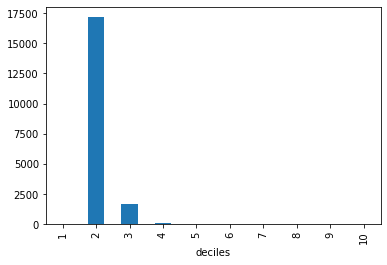

```python
actors_acc_df.groupby('deciles').count()['profit'].plot(kind = 'bar');
```

That can't be right, right? something is off here, let's have a look at the actual data used for the plot

```python
actors_acc_df.groupby('deciles').count()['profit']
```

```
deciles
1         2
2     17179
3      1667
4        65
5        13
6         2
7         1
8         0
9         0
10        1
Name: profit, dtype: int64
```

Now, it makes sense, what the data says is that the average profit of the movies in which the number one actor plays is so big that in the next steps there is no one. About the steps, we divided the data in difererent bins, for instance say the the profit column is made of numbers from 1 to 100 then the 10 bins would be 1-10, 11-20 .... 91-100, well in this case in categories 8 and 9 there is simply no one :( in fact let's have a look at the categories ranges

```python
actors_acc_df['ranges'] = pd.cut(actors_acc_df.profit, bins = 10)
```

```python
actors_acc_df.groupby('ranges').count()['profit']
```

```
ranges
(-416194521.656, -185703365.4]        2
(-185703365.4, 42505700.2]        17179
(42505700.2, 270714765.8]          1667
(270714765.8, 498923831.4]           65
(498923831.4, 727132897.0]           13
(727132897.0, 955341962.6]            2
(955341962.6, 1183551028.2]           1
(1183551028.2, 1411760093.8]          0
(1411760093.8, 1639969159.4]          0
(1639969159.4, 1868178225.0]          1
Name: profit, dtype: int64
```

However this data is not very conclusive, let's see the actors who play on in profitable movies on average, for this we will create a new column 'positive' where we will insert a 1 if the average profit is positive and 0 if it is negative. In order to achieve this we will create a function that will take row as parameter and will return 0 or 1 as described above

```python
def positive_profit (row):
    if row['profit'] > 0:
        return 1
    else:
        return 0


actors_acc_df['pos_profit'] = actors_acc_df.apply(positive_profit, axis=1)
actors_acc_df.head()
```

|  | cast | profit | deciles | ranges | pos_profit |
| --- | --- | --- | --- | --- | --- |
| 3880 | Daisy Ridley | 1.868178e+09 | 10 | (1639969159.4, 1868178225.0] | 1 |
| 16045 | Santino Fontana | 1.124219e+09 | 7 | (955341962.6, 1183551028.2] | 1 |
| 2113 | Bob Peck | 8.571000e+08 | 6 | (727132897.0, 955341962.6] | 1 |
| 15319 | Robert MacNaughton | 7.824106e+08 | 6 | (727132897.0, 955341962.6] | 1 |
| 14432 | Phaldut Sharma | 6.113927e+08 | 5 | (498923831.4, 727132897.0] | 1 |

let's see now how is distribution between negative and positive values

```python
actors_acc_df.groupby('pos_profit').count()['profit']
```

```
pos_profit
0    12107
1     6823
Name: profit, dtype: int64
```

Let's see it in a bar chart

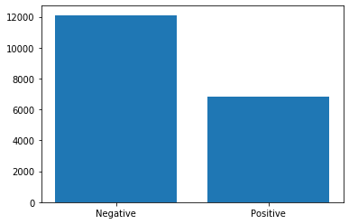

```python
plt.bar([0, 1],actors_acc_df.groupby('pos_profit').count()['profit'].values)
plt.xticks([0,1], ('Negative', 'Positive'))
plt.show()
```

#### So, in order to answer the initial question, now we have a list of little more then 6000 actors who on average tend to play on profitable productions

#### *Limitations of the actors section*

#### *This text is emphasized on porpuse, the simple fact that an actor appears on the cast of a few profitable movies does not mean that his/her presence was such a monumental presence that influenced this movies to be profitable. The same applies to the following categories also. The only thing that this data shows is that when looking at factors that influence the profitability of a movie, maybe an investor should not put too much weight on the stardom of the cast that will play in the movie, but rather concentrate on people who were in succesful productions:*

> as Maia Morgenstern can attest,  
> Sylvester is not the best :)

## Directors

Following the approach in the last section we will now try to see who tends to direct profitable movies, as with the the cast approach we will have a look at the data, make necesary adjustments, and we will compute the average profitability of the movie per director. **Let's begin!!!**

First things first, we will create a new dataframe

```python
directors_df = movies_df.copy()
```

Let's have a closer look at the Driectors column

```python
directors_df['director'].head()
```

```
0     Colin Trevorrow
1       George Miller
2    Robert Schwentke
3         J.J. Abrams
4           James Wan
Name: director, dtype: object
```

And let's look again at the data frame

```python
directors_df.info()
```

```
<class 'pandas.core.frame.DataFrame'>
Int64Index: 10731 entries, 0 to 10865
Data columns (total 10 columns):
 #   Column          Non-Null Count  Dtype
---  ------          --------------  -----
 0   budget          10731 non-null  int64
 1   revenue         10731 non-null  int64
 2   original_title  10731 non-null  object
 3   cast            10731 non-null  object
 4   director        10731 non-null  object
 5   genres          10731 non-null  object
 6   release_date    10731 non-null  object
 7   budget_adj      10731 non-null  float64
 8   revenue_adj     10731 non-null  float64
 9   profit_adj      10731 non-null  float64
dtypes: float64(3), int64(2), object(5)
memory usage: 922.2+ KB
```

it seems that there is one director per row, as an aditional chech we can look for the '|' character in the column

```python
directors_df.director.str.find('|').sum()
```

```
-476
```

When the value is not found the .find() function returns -1 for the row, therefore, if there was onle one director per movie we should have had the sum - 10731, yet the value is -476 let's investigate further

```python
directors_df['lone_dir'] = directors_df.director.str.find('|')
```

In the above cell we create a new column where if there is a single director it will hold -1, otherwise it will hold the first instance of '|' character.

```python
directors_df[directors_df['lone_dir'] != -1].head()
```

|  | budget | revenue | original_title | cast | director | genres | release_date | budget_adj | revenue_adj | profit_adj | lone_dir |
| --- | --- | --- | --- | --- | --- | --- | --- | --- | --- | --- | --- |
| 8 | 74000000 | 1156730962 | Minions | Sandra Bullock\|Jon Hamm\|Michael Keaton\|Allison... | Kyle Balda\|Pierre Coffin | Family\|Animation\|Adventure\|Comedy | 6/17/15 | 6.807997e+07 | 1.064192e+09 | 9.961120e+08 | 10 |
| 11 | 176000003 | 183987723 | Jupiter Ascending | Mila Kunis\|Channing Tatum\|Sean Bean\|Eddie Redm... | Lana Wachowski\|Lilly Wachowski | Science Fiction\|Fantasy\|Action\|Adventure | 2/4/15 | 1.619199e+08 | 1.692686e+08 | 7.348699e+06 | 14 |
| 64 | 50100000 | 153962963 | Focus | Will Smith\|Margot Robbie\|Rodrigo Santoro\|Rober... | Glenn Ficarra\|John Requa | Romance\|Comedy\|Crime\|Drama | 2/25/15 | 4.609198e+07 | 1.416459e+08 | 9.555388e+07 | 13 |
| 85 | 31000000 | 104384188 | Vacation | Ed Helms\|Christina Applegate\|Skyler Gisondo\|St... | John Francis Daley\|Jonathan M. Goldstein | Adventure\|Comedy | 7/28/15 | 2.851999e+07 | 9.603341e+07 | 6.751342e+07 | 18 |
| 100 | 0 | 0 | Frozen Fever | Kristen Bell\|Idina Menzel\|Jonathan Groff\|Josh ... | Chris Buck\|Jennifer Lee | Adventure\|Animation\|Family | 3/9/15 | 0.000000e+00 | 0.000000e+00 | 0.000000e+00 | 10 |

As expected, we should make some adjustments to the data, first we will "explode" the director column in such a way that there will be only one director per column, and second, we shall create a new column, the profit, this time only we will take the unadjusted profit, as we want our computation to favour the directors who directed more recent movies, for the potential investor, remember?

Just to be safe, let's create another data frame for the following operations

```python
directs_help_df = directors_df.copy()
```

```python
#adding the profit column
directs_help_df['profit'] = directs_help_df['revenue'] - directs_help_df['budget']
# and a quick look
directs_help_df.head(1)
```

|  | budget | revenue | original_title | cast | director | genres | release_date | budget_adj | revenue_adj | profit_adj | lone_dir | profit |
| --- | --- | --- | --- | --- | --- | --- | --- | --- | --- | --- | --- | --- |
| 0 | 150000000 | 1513528810 | Jurassic World | Chris Pratt\|Bryce Dallas Howard\|Irrfan Khan\|Vi... | Colin Trevorrow | Action\|Adventure\|Science Fiction\|Thriller | 6/9/15 | 1.379999e+08 | 1.392446e+09 | 1.254446e+09 | -1 | 1363528810 |

```python
#selecting director and profit columns
directs_help_df = directs_help_df[['director', 'profit']]
# confirming the operation
directs_help_df.head(1)
```

|  | director | profit |
| --- | --- | --- |
| 0 | Colin Trevorrow | 1363528810 |

```python
#splitting the director strings by the '|' character
directs_help_df['director'] = directs_help_df['director'].str.split('|')
```

Now if you scroll a bit up you will see that there is a table with values where there is more than one director, bellow we want to see the how the strings are splitted, therefore we will randomly select the rows with numbers 64 (more than one director) and 65, which is 64+1

```python
directs_help_df.iloc[64:66, :]
```

|  | director | profit |
| --- | --- | --- |
| 64 | [Glenn Ficarra, John Requa] | 103862963 |
| 65 | [Aleksander Bach] | 47347656 |

Now let's explode the director column the same way we did with the actors column

```python
# explosion of the actors
# actors_df = actors_df.explode('cast')
directs_help_df = directs_help_df.explode('director')
# as usual, let's have a look at the results
directs_help_df.head()
```

|  | director | profit |
| --- | --- | --- |
| 0 | Colin Trevorrow | 1363528810 |
| 1 | George Miller | 228436354 |
| 2 | Robert Schwentke | 185238201 |
| 3 | J.J. Abrams | 1868178225 |
| 4 | James Wan | 1316249360 |

And specifically at rows 64 and let's go to 69 this time

```python
directs_help_df.iloc[64:70]
```

|  | director | profit |
| --- | --- | --- |
| 62 | Robert Eggers | 36923945 |
| 63 | Paul Feig | 170666219 |
| 64 | Glenn Ficarra | 103862963 |
| 64 | John Requa | 103862963 |
| 65 | Aleksander Bach | 47347656 |
| 66 | Ron Howard | -6179242 |

Well, the indexes are a bit off, but, the results are the intended ones

Let's group the results by director

```python
direct_group = directs_help_df.groupby('director').mean()
# and let's have a look at the results
direct_group.head(2)
```

| director | profit |
| --- | --- |
| Frédéric Jardin | -2496642.0 |
| A. Todd Smith | 0.0 |

Yes, that is correct we should sort the values

```python
direct_group.sort_values(by = 'profit', inplace=True, ascending=False)
#let's see
direct_group.head(3)
```

| director | profit |
| --- | --- |
| Pierre Coffin | 8.173356e+08 |
| Colin Trevorrow | 6.833933e+08 |
| David Yates | 6.758591e+08 |

And we got the winners, let's look at the first 10, maybe we recognize somebody

```python
direct_group.head(10)
```

| director | profit |
| --- | --- |
| Pierre Coffin | 8.173356e+08 |
| Colin Trevorrow | 6.833933e+08 |
| David Yates | 6.758591e+08 |
| Lee Unkrich | 6.191573e+08 |
| Robert Stromberg | 5.784104e+08 |
| J.J. Abrams | 5.678340e+08 |
| Jennifer Lee | 5.621095e+08 |
| Bob Peterson | 5.563427e+08 |
| Chris Miller | 5.319728e+08 |
| Conrad Vernon | 5.260900e+08 |

Well, big names present, many big names absent :( and to my personal sorrow the director of Rocky is not in the above list

let's have a look at the bottom 10 maybe we know somebody there

```python
direct_group.tail(10)
```

| director | profit |
| --- | --- |
| Lawrence Kasanoff | -64926294.0 |
| Joan Chen | -65000000.0 |
| Joby Harold | -71626175.0 |
| David A. Armstrong | -83000000.0 |
| Aaron Blaise | -99999750.0 |
| Robert Walker | -99999750.0 |
| Tim Van Patten | -120000000.0 |
| Jeremy Podeswa | -120000000.0 |
| Graham Yost | -120000000.0 |
| Sngmoo Lee | -413912431.0 |

Saddly no one I know :(

I am also curious about the descriptive statistics of this Data Frame

```python
direct_group.describe()
```

|  | profit |
| --- | --- |
| count | 5.298000e+03 |
| mean | 1.234008e+07 |
| std | 5.172029e+07 |
| min | -4.139124e+08 |
| 25% | 0.000000e+00 |
| 50% | 0.000000e+00 |
| 75% | 2.064839e+06 |
| max | 8.173356e+08 |

Inconclusive, let's hee how is the distribution by deciles by the number of directors, in order to do this we will create a new column called deciles, using the cut function, where the number of the decile will appear in the row with the director's name, afterwards, we shall group by deciles with the count fucntion and plot the results

```python
direct_group['deciles'] = pd.cut(direct_group.profit, bins = 10, labels=np.r_[1:11:1])
```

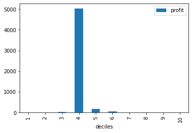

```python
direct_group.groupby('deciles').count().plot(kind = 'bar');
```

As we can see most of the directors fall in the 4th decile, just bellow average when it comes to average earnings per movie, what I can say is that it is a tough job to be in, where a select few make it to the top

Let's see now how many directors make profitable movies on average and how many not, we will apply the same principle as with the actors

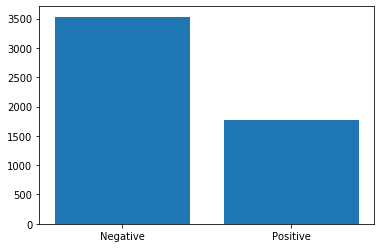

```python
#dividing in positive and negative
direct_group['pos_profit'] = direct_group.apply(positive_profit, axis=1)
#preparing the plot for positive and negatives
plt.bar([0, 1],direct_group.groupby('pos_profit').count()['profit'].values)
plt.xticks([0,1], ('Negative', 'Positive'))
#showing the plot
plt.show()
```

**This answers the question *Who tends to direct profitable movies?* our potential investor can concentrate his efforts on the directors who on average direct profitable movies**

**Moreover, the same disclaimer from the previous section also applies here.**

### Genres

The last category to be analised is the genres category, we will apply the same approach as with the others:

1. Create the profit column
2. Split the genres category by the '|' symbol
3. explode the column genres and group it

Since the approach is the same we shall not go into much detail for this category

```python
# first let's create a copy of data frame
genres_df = movies_df.copy()
```

```python
# creating the profit column
genres_df['profit'] = genres_df['revenue'] - genres_df['budget']
```

```python
#selecting only the needed columns
genres_df = genres_df[['genres', 'profit']]
```

```python
#splitting the genres column by the '|' character
genres_df['genres'] = genres_df['genres'].str.split('|')
```

```python
#exploding the new genres column
genres_df = genres_df.explode('genres')
```

```python
#grouping by genre
genres_df = genres_df.groupby('genres').mean()

# and looking at the final result
genres_df
```

| genres | profit |
| --- | --- |
| Action | 4.521865e+07 |
| Adventure | 7.590377e+07 |
| Animation | 5.484601e+07 |
| Comedy | 2.434341e+07 |
| Crime | 2.472312e+07 |
| Documentary | 1.586813e+06 |
| Drama | 1.740300e+07 |
| Family | 4.976972e+07 |
| Fantasy | 6.426782e+07 |
| Foreign | 5.112328e+04 |
| History | 1.360071e+07 |
| Horror | 1.060276e+07 |
| Music | 1.958275e+07 |
| Mystery | 2.415795e+07 |
| Romance | 2.321095e+07 |
| Science Fiction | 4.546382e+07 |
| TV Movie | -1.666667e+04 |
| Thriller | 2.456400e+07 |
| War | 2.691265e+07 |
| Western | 9.653105e+06 |

lets sort the categories ascending

```python
genres_df.sort_values(inplace=True, ascending=True, by = 'profit')
```

And to have a better view let's plot a barplot

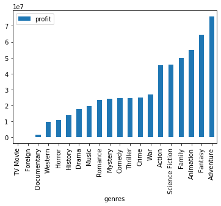

```python
genres_df.plot(kind = 'bar');
```

#### Talking about the potential investor from the begining of this paper, I would not go for movies left of western, anyway we have birds view of the answer to the question what tends to make a profit ?

### Conclusions

The relevant conclusions were drawn at the end of each section. As a conclusion for this paper, I want to emphasize again the limitations and the approach taken to arrive at the above mentioned conclusions.  
First **the approach**  
I took the actors, namely one actor, and divided the sum of the profits of every movie he has played in by the said number of movies. This number tells us the average profit of the movies in which said actor was cast. This way a potential investor can have a reliable picture of the averages of the factors analysed above. Yet, art does not abide by the law of the averages we saw that the "profit" for one actor is two deciles further apart to the next one, we also saw the directors and genres that tend to be succesfull, again on average.  
Now, **the limitations** of this approach is that we cannot use this data to reliably asses if the next movie the said actor will play in will be a profitable movie or it is going to be a flop. It tells the investor where he could look